# Homework 3 Solution

## Problem 1 - Max Flow Modeling

A Dungeon Master (DM) is trying to plan for the next three campaigns she is running. She runs campaigns for four different groups, and she is hoping to finish the groups' campaigns in the next six months.

- Group 1's campaign must be completed no later than 4 months from now and will require 20 total hours of play-time
- Group 2's campaign must be completed no later than 5 months from now and will require 18 total hours of play-time
- Group 3's campaign must be completed no later than 6 months from now and will require 13 total hours of play-time
- Group 4's campaign must be completed no later than 3 months from now and will require 14 total hours of play-time

Each month, 12 hours are available for playing games. During a given month, no more than 8 hours can be spent on the same campaign.

Formulate a *maximum flow problem* whose solution will determine whether or not all four campaigns can be completed on time. Your answer should clearly draw the network, the source node, the sink node, and capacity on each arc in the network. Upload a picture of the network with your solution.

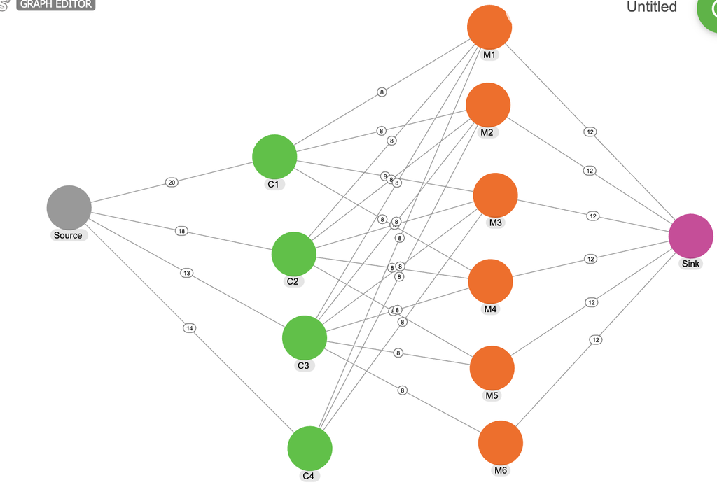

Note: There should be an extra line from sink to source with 100 as the edge cost

```julia
using JuMP, Clp
A = [1  1  1  1  0  0  0  0  0  0  0  0  0  0  0  0  0  0  0  0  0  0  0  0  0  0  0  0 -1#Node: Source
    -1  0  0  0  1  1  1  1  0  0  0  0  0  0  0  0  0  0  0  0  0  0  0  0  0  0  0  0  0#Node: C1
     0 -1  0  0  0  0  0  0  1  1  1  1  1  0  0  0  0  0  0  0  0  0  0  0  0  0  0  0  0#Node: C2
     0  0 -1  0  0  0  0  0  0  0  0  0  0  1  1  1  1  1  1  0  0  0  0  0  0  0  0  0  0#Node: C3
     0  0  0 -1  0  0  0  0  0  0  0  0  0  0  0  0  0  0  0  1  1  1  0  0  0  0  0  0  0#Node: C4
     0  0  0  0 -1  0  0  0 -1  0  0  0  0 -1  0  0  0  0  0 -1  0  0  1  0  0  0  0  0  0#Node: M1
     0  0  0  0  0 -1  0  0  0 -1  0  0  0  0 -1  0  0  0  0  0 -1  0  0  1  0  0  0  0  0#Node: M2
     0  0  0  0  0  0 -1  0  0  0 -1  0  0  0  0 -1  0  0  0  0  0 -1  0  0  1  0  0  0  0#Node: M3
     0  0  0  0  0  0  0 -1  0  0  0 -1  0  0  0  0 -1  0  0  0  0  0  0  0  0  1  0  0  0#Node: M4
     0  0  0  0  0  0  0  0  0  0  0  0 -1  0  0  0  0 -1  0  0  0  0  0  0  0  0  1  0  0#Node: M5
     0  0  0  0  0  0  0  0  0  0  0  0  0  0  0  0  0  0 -1  0  0  0  0  0  0  0  0  1  0#Node: M6
     0  0  0  0  0  0  0  0  0  0  0  0  0  0  0  0  0  0  0  0  0  0 -1 -1 -1 -1 -1 -1  1]#Node: Sink
b = [0, 0, 0, 0, 0, 0, 0, 0, 0, 0, 0, 0]
c = [0, 0, 0, 0, 0, 0, 0, 0, 0, 0, 0, 0, 0, 0, 0, 0, 0, 0, 0, 0, 0, 0, 0, 0, 0, 0, 0, 0, -1]
cap = [20, 18, 13, 14, 8,8,8,8,8,8,8,8,8,8,8,8,8,8,8,8,8,8,12,12,12,12,12,12, 100]
m = Model(Clp.Optimizer)
@variable(m, x[1:29] >= 0)
@constraint(m, A*x .== b)
@constraint(m, x .<= cap)
@objective(m, Min, sum(c[i]*x[i] for i in 1:29))
optimize!(m)

println("Total flow through network: ", -objective_value(m))
println("Flow on each arc: ")
println("S-C1: ", value(x[1]))
println("S-C2: ", value(x[2]))
println("S-C3: ", value(x[3]))
println("S-C4: ", value(x[4]))
println("C1-M1: ", value(x[5]))
println("C1-M2: ", value(x[6]))
println("C1-M3: ", value(x[7]))
println("C1-M4: ", value(x[8]))
println("C2-M1: ", value(x[9]))
println("C2-M2: ", value(x[10]))
println("C2-M3: ", value(x[11]))
println("C2-M4: ", value(x[12]))
println("C2-M5: ", value(x[13]))
println("C3-M1: ", value(x[14]))
println("C3-M2: ", value(x[15]))
println("C3-M3: ", value(x[16]))
println("C3-M4: ", value(x[17]))
println("C3-M5: ", value(x[18]))
println("C3-M6: ", value(x[19]))
println("C4-M1: ", value(x[20]))
println("C4-M2: ", value(x[21]))
println("C4-M3: ", value(x[22]))
println("M1-Sink: ", value(x[23]))
println("M2-Sink: ", value(x[24]))
println("M3-Sink: ", value(x[25]))
println("M4-Sink: ", value(x[26]))
println("M5-Sink: ", value(x[27]))
println("M6-Sink: ", value(x[28]))
println("Dummy: ", value(x[29]))
```

```
Total flow through network: 65.0
Flow on each arc:
S-C1: 20.0
S-C2: 18.0
S-C3: 13.0
S-C4: 14.0
C1-M1: 0.0
C1-M2: 4.0
C1-M3: 8.0
C1-M4: 8.0
C2-M1: 5.0
C2-M2: 0.0
C2-M3: 1.0
C2-M4: 4.0
C2-M5: 8.0
C3-M1: 1.0
C3-M2: 0.0
C3-M3: 0.0
C3-M4: 0.0
C3-M5: 4.0
C3-M6: 8.0
C4-M1: 6.0
C4-M2: 8.0
C4-M3: 0.0
M1-Sink: 12.0
M2-Sink: 12.0
M3-Sink: 9.0
M4-Sink: 12.0
M5-Sink: 12.0
M6-Sink: 8.0
Dummy: 65.0
Coin0506I Presolve 10 (-31) rows, 27 (-2) columns and 54 (-33) elements
Clp0006I 0  Obj 0 Dual inf 3.999996 (4)
Clp0006I 21  Obj -65
Clp0000I Optimal - objective value -65
Coin0511I After Postsolve, objective -65, infeasibilities - dual 0 (0), primal 0 (0)
Clp0032I Optimal objective -65 - 21 iterations time 0.002, Presolve 0.00
```

## Problem 2 - The Duality of Plushies

Assemble-an-Animal is currently producing four plushies: pandas, panthers, pangolins, and penguins.

A pangolin for reference:

[figure not shown]

The profit contribution, labor hours, and raw material usage (in square feet) per plushie for each type of animal are given below:

| Plushie | Profit (\$) | Labor (Hr.) | Raw Material (ft$^2$) |
| --- | --- | --- | --- |
| Panda | 70 | 2 | 5 |
| Panther | 110 | 3 | 5 |
| Pangolin | 300 | 3 | 10 |
| Penguin | 250 | 5 | 15 |

A maximum of 10,000 labor hours and 35,000 square feet of raw material are available annually. Each panda plushie spends an average of 0.25 year in storage; panther plushies an average of 1 year; pangolin plushies, an average of 2 years; penguin plushies, an average of 3.5 years. The warehouse can handle an average inventory level of 5,000 total plushies. Determine how much of each type of plushie should be produced annually to maximize Assemble-an-Animal's profit.

A linear program model for this problem is:

$\begin{alignat*}{5} \max \ & z = & 70x_1 &+& 110x_2 &+& 300x_3 &+& 250x_4 & \\ \text{s.t. } & & 2x_1 &+& 3x_2 &+&3x_3&+&5 x_4 & \leq 10000 \\ & & 5x_1 &+& 5x_2 &+&10x_3 &+&15x_4 & \leq 35000 \\ & & 0.25 x_1 &+& x_2 &+&2x_3 &+& 3.5 x_4 & \leq 5000\\ & & \qquad \qquad x_1 \geq 0, & &\ x_2 \geq 0, & &x_3 \geq 0, & &x_4 \geq 0 \end{alignat*}$

where $x_j$ is the number of plushies of type $j$ to produce each year.

In the sensitivity analysis questions below, answer each question *independently* (e.g., when answering part (c), consider only the changes suggested in part (c), not those in addition to the ones considered in part (b)).

(a) Solve this model in Julia/JuMP and give the optimal primal and dual solutions, and the optimal objective function value.

(b) What is the maximum amount Assemble-an-Animal should be willing to pay for an additional hour of labor?

(c) The marketing department is considering running an advertising campaign that would increase the profit per panther plushie by \$10 and panda plushie by \\$15. Provide an estimate of the new optimal profit ($z^*_{NEW}$) after this change and indicate if your estimate is a lower or upper bound on the new optimal profit. Your answer should be of the form $z^*_{NEW} \geq \underline{\phantom{aaaa}}$ or $z^*_{NEW} \leq \underline{\phantom{aaaa}}$, where you fill in a number in the blank.

(d) Assemble-an-Animal is considering a facility redesign that would decrease the labor availability by 1000 hours, but increase the raw material availability by 4000 square feet. Provide an estimate of the new optimal profit ($z^*_{NEW}$) after this change and indicate if your estimate is a lower or upper bound on the new optimal profit. Your answer should be of the form $z^*_{NEW} \geq \underline{\phantom{aaaa}}$ or $z^*_{NEW} \leq \underline{\phantom{aaaa}}$, where you fill in a number in the blank.

## The Primal of Plushies

```julia
using JuMP, Clp

m = Model(Clp.Optimizer)

@variable(m, x1 >= 0)
@variable(m, x2 >= 0)
@variable(m, x3 >= 0)
@variable(m, x4 >= 0)
@constraint(m, One, 2*x1 + 3*x2 + 3*x3 + 5*x4 <= 10000)
@constraint(m, Two, 5*x1 + 5*x2 + 10*x3 + 15*x4 <= 35000)
@constraint(m, Three, 0.25*x1 + 1*x2 + 2*x3 + 3.5*x4 <= 5000)
@objective(m, Max, 70*x1 + 110*x2 + 300*x3 + 250*x4)

# solve this instance of the Top Brass problem
optimize!(m)

# print out the full model and solution
println(m)

println("x1: ", value(x1))
println("x2:  ", value(x2))
println("x3:  ", value(x3))
println("x4:  ", value(x4))
println("Optimal objective: ", objective_value(m))
```

```
Max 70 x1 + 110 x2 + 300 x3 + 250 x4
Subject to
 One : 2 x1 + 3 x2 + 3 x3 + 5 x4 ≤ 10000
 Two : 5 x1 + 5 x2 + 10 x3 + 15 x4 ≤ 35000
 Three : 0.25 x1 + x2 + 2 x3 + 3.5 x4 ≤ 5000
 x1 ≥ 0
 x2 ≥ 0
 x3 ≥ 0
 x4 ≥ 0

x1: 1538.4615384615388
x2:  0.0
x3:  2307.6923076923076
x4:  0.0
Optimal objective: 800000.0
Coin0506I Presolve 3 (0) rows, 4 (0) columns and 12 (0) elements
Clp0006I 0  Obj 0 Dual inf 420.70276 (4)
Clp0006I 2  Obj 800000
Clp0000I Optimal - objective value 800000
Clp0032I Optimal objective 800000 - 2 iterations time 0.002
```

## The Duality of Plushies

```julia
using JuMP, Clp

m = Model(Clp.Optimizer)
@variable(m, λ[1:3] >= 0)

@constraint(m, 2λ[1] + 5λ[2] + 0.25λ[3] >= 70)
@constraint(m, 3λ[1] + 5λ[2] + 1λ[3] >= 110)
@constraint(m, 3λ[1] + 10λ[2] + 2λ[3] >= 300)
@constraint(m, 5λ[1] + 15λ[2] + 3.5λ[3] >= 250)

@objective(m, Min, 10000*λ[1] + 35000*λ[2] + 5000*λ[3])

optimize!(m)

println(m)

println("dual variables are: ", value.(λ))
println("Optimal objective is: ", objective_value(m))
```

```
Min 10000 λ[1] + 35000 λ[2] + 5000 λ[3]
Subject to
 2 λ[1] + 5 λ[2] + 0.25 λ[3] ≥ 70
 3 λ[1] + 5 λ[2] + λ[3] ≥ 110
 3 λ[1] + 10 λ[2] + 2 λ[3] ≥ 300
 5 λ[1] + 15 λ[2] + 3.5 λ[3] ≥ 250
 λ[1] ≥ 0
 λ[2] ≥ 0
 λ[3] ≥ 0

dual variables are: [20.0, 0.0, 119.99999999999999]
Optimal objective is: 799999.9999999999
Coin0506I Presolve 4 (0) rows, 3 (0) columns and 12 (0) elements
Clp0006I 0  Obj 0 Primal inf 82.666666 (4)
Clp0006I 2  Obj 800000
Clp0000I Optimal - objective value 800000
Clp0032I Optimal objective 800000 - 2 iterations time 0.002
```

## (b)

```julia
using JuMP, Clp

m = Model(Clp.Optimizer)

@variable(m, x1 >= 0)
@variable(m, x2 >= 0)
@variable(m, x3 >= 0)
@variable(m, x4 >= 0)
@constraint(m, One, 2*x1 + 3*x2 + 3*x3 + 5*x4 <= 10001)  #Change from 10000 hours of labor to 10001
@constraint(m, Two, 5*x1 + 5*x2 + 10*x3 + 15*x4 <= 35000)
@constraint(m, Three, 0.25*x1 + 1*x2 + 2*x3 + 3.5*x4 <= 5000)
@objective(m, Max, 70*x1 + 110*x2 + 300*x3 + 250*x4)

# solve this instance of the Top Brass problem
optimize!(m)

# print out the full model and solution
println(m)

println("x1: ", value(x1))
println("x2:  ", value(x2))
println("x3:  ", value(x3))
println("x4:  ", value(x4))
println("The maximum amount Assemble-an-Animal should be willing to pay for an additional hour of labor ", objective_value(m)-800000)
```

```
Max 70 x1 + 110 x2 + 300 x3 + 250 x4
Subject to
 One : 2 x1 + 3 x2 + 3 x3 + 5 x4 ≤ 10001
 Two : 5 x1 + 5 x2 + 10 x3 + 15 x4 ≤ 35000
 Three : 0.25 x1 + x2 + 2 x3 + 3.5 x4 ≤ 5000
 x1 ≥ 0
 x2 ≥ 0
 x3 ≥ 0
 x4 ≥ 0

x1: 1539.076923076923
x2:  0.0
x3:  2307.6153846153843
x4:  0.0
The maximum amount Assemble-an-Animal should be willing to pay for an additional hour of labor 19.999999999883585
Coin0506I Presolve 3 (0) rows, 4 (0) columns and 12 (0) elements
Clp0006I 0  Obj 0 Dual inf 420.70276 (4)
Clp0006I 2  Obj 800020
Clp0000I Optimal - objective value 800020
Clp0032I Optimal objective 800020 - 2 iterations time 0.002
```

## (c)

Because p *= d*, changing 70 to 85 increases both p *and d* by 15x1.  
Because p *= d*, changing 110 to 120 increases both p *and d* by 10x2.  
In this case, the total profit will be increases by 15*1538.4615384615388 =23076.923076923

$z^*_{NEW} \leq \underline{823076.923076923}$

```julia
using JuMP, Clp

m = Model(Clp.Optimizer)

@variable(m, x1 >= 0)
@variable(m, x2 >= 0)
@variable(m, x3 >= 0)
@variable(m, x4 >= 0)
@constraint(m, One, 2*x1 + 3*x2 + 3*x3 + 5*x4 <= 10000)
@constraint(m, Two, 5*x1 + 5*x2 + 10*x3 + 15*x4 <= 35000)
@constraint(m, Three, 0.25*x1 + 1*x2 + 2*x3 + 3.5*x4 <= 5000)
@objective(m, Max, 85*x1 + 120*x2 + 300*x3 + 250*x4)

# solve this instance of the Top Brass problem
optimize!(m)

# print out the full model and solution
println(m)

println("x1: ", value(x1))
println("x2:  ", value(x2))
println("x3:  ", value(x3))
println("x4:  ", value(x4))
println("Optimal objective: ", objective_value(m))
```

```
Max 85 x1 + 120 x2 + 300 x3 + 250 x4
Subject to
 One : 2 x1 + 3 x2 + 3 x3 + 5 x4 ≤ 10000
 Two : 5 x1 + 5 x2 + 10 x3 + 15 x4 ≤ 35000
 Three : 0.25 x1 + x2 + 2 x3 + 3.5 x4 ≤ 5000
 x1 ≥ 0
 x2 ≥ 0
 x3 ≥ 0
 x4 ≥ 0

x1: 1538.4615384615388
x2:  0.0
x3:  2307.6923076923076
x4:  0.0
Optimal objective: 823076.923076923
Coin0506I Presolve 3 (0) rows, 4 (0) columns and 12 (0) elements
Clp0006I 0  Obj 0 Dual inf 453.77398 (4)
Clp0006I 2  Obj 823076.92
Clp0000I Optimal - objective value 823076.92
Clp0032I Optimal objective 823076.9231 - 2 iterations time 0.002
```

## (d)

Because p *= d* (by Strong Duality), changing 10000 to 9000 decreases both p *and d* by -1000𝜆1  
Because p *= d* (by Strong Duality), changing 35000 to 39000 decreases both p *and d* by 4000𝜆2  
In this case, the total profit will be decreases by: -1000*20.0 + 0*4000 = -20000.

```julia
using JuMP, Clp

m = Model(Clp.Optimizer)
@variable(m, λ[1:3] >= 0)

@constraint(m, 2λ[1] + 5λ[2] + 0.25λ[3] >= 70)
@constraint(m, 3λ[1] + 5λ[2] + 1λ[3] >= 110)
@constraint(m, 3λ[1] + 10λ[2] + 2λ[3] >= 300)
@constraint(m, 5λ[1] + 15λ[2] + 3.5λ[3] >= 250)

@objective(m, Min, 9000*λ[1] + 39000*λ[2] + 5000*λ[3])

optimize!(m)

println(m)

println("dual variables are: ", value.(λ))
println("Optimal objective is: ", objective_value(m))
```

```
Min 9000 λ[1] + 39000 λ[2] + 5000 λ[3]
Subject to
 2 λ[1] + 5 λ[2] + 0.25 λ[3] ≥ 70
 3 λ[1] + 5 λ[2] + λ[3] ≥ 110
 3 λ[1] + 10 λ[2] + 2 λ[3] ≥ 300
 5 λ[1] + 15 λ[2] + 3.5 λ[3] ≥ 250
 λ[1] ≥ 0
 λ[2] ≥ 0
 λ[3] ≥ 0

dual variables are: [20.0, 0.0, 119.99999999999999]
Optimal objective is: 779999.9999999999
Coin0506I Presolve 4 (0) rows, 3 (0) columns and 12 (0) elements
Clp0006I 0  Obj 0 Primal inf 82.666666 (4)
Clp0006I 2  Obj 780000
Clp0000I Optimal - objective value 780000
Clp0032I Optimal objective 780000 - 2 iterations time 0.002
```

## Problem 3 - Duality and complementarity

Consider the following linear program:

\begin{align} \min z = 2 x_1 + x_3 & \label{eq:lp-duality-6} \\ \mbox{s.t.} \quad x_1 + x_2 - x_3 &\geq 5\nonumber\\ x_1 - 2 x_2 + 4 x_3 &\geq 8\nonumber\\ x_1, x_2, x_3 &\geq 0 \nonumber \end{align}

(1) Give the dual of this linear program.

(2) Find a complementary dual solution to the primal solution: $ \hat{x} := (\hat{x}_1, \hat{x}_2, \hat{x}_3) = \left(\frac{28}{5}, 0, \frac{3}{5} \right) $

(3) Is your dual solution feasible? What can you conclude about $\hat{x}$?

(4) Draw the feasible region to the dual you derived in (1). Find the optimal dual solution by the graphical method.

(5) Use complementary slackness and your dual solution from (4) to fimd the optimal primal solution.

## (1)

Original:

```julia
using Clp, JuMP

m = Model(Clp.Optimizer)

@variable(m,x1>=0)
@variable(m,x2>=0)
@variable(m,x3>=0)

@objective(m, Min, 2x1 + x3)

@constraint(m, c1, x1+x2-x3 >= 5)
@constraint(m, c2, x1 - 2x2 +4x3>= 8)

optimize!(m)
println(m)
println("x1 = ", value(x1))
println("x2 = ", value(x2))
println("x3 = ", value(x3))

println("objective = ", objective_value(m))
```

```
Min 2 x1 + x3
Subject to
 c1 : x1 + x2 - x3 ≥ 5
 c2 : x1 - 2 x2 + 4 x3 ≥ 8
 x1 ≥ 0
 x2 ≥ 0
 x3 ≥ 0

x1 = 0.0
x2 = 14.0
x3 = 9.0
objective = 9.0
Coin0506I Presolve 2 (0) rows, 3 (0) columns and 6 (0) elements
Clp0006I 0  Obj 0 Primal inf 6.9999998 (2)
Clp0006I 2  Obj 9
Clp0000I Optimal - objective value 9
Clp0032I Optimal objective 9 - 2 iterations time 0.002
```

Duality:  
Change from min to max  
max -2u-w  
-u-v+w <= -5  
-u+2v-4w <= -8  
u, v, w >= 0

```julia
using Clp, JuMP

m = Model(Clp.Optimizer)

@variable(m,u>=0)
@variable(m,v>=0)
@variable(m,w>=0)

@objective(m, Max, -2*u - w)

@constraint(m, c1, -u-v+w <= -5)
@constraint(m, c2, -u+2v-4w <= -8)

optimize!(m)
println(m)
println("u = ", value(u))
println("v = ", value(v))
println("w = ", value(w))

println("objective = ", -objective_value(m))
```

```
Max -2 u - w
Subject to
 c1 : -u - v + w ≤ -5
 c2 : -u + 2 v - 4 w ≤ -8
 u ≥ 0
 v ≥ 0
 w ≥ 0

u = 0.0
v = 14.0
w = 9.0
objective = 9.0
Coin0506I Presolve 2 (0) rows, 3 (0) columns and 6 (0) elements
Clp0006I 0  Obj 0 Primal inf 6.9999998 (2)
Clp0006I 2  Obj -9
Clp0000I Optimal - objective value -9
Clp0032I Optimal objective -9 - 2 iterations time 0.002
```

```julia
using JuMP, Clp

m = Model(Clp.Optimizer)
@variable(m, λ[1:2] >= 0) # variables for each primal constraint

# constraints ensuring the correct relationship with each primal variable
# to guarantee an upper bound
@constraint(m, -1λ[1] - 1λ[2] >= -2)
@constraint(m, -1λ[1] + 2λ[2] >= 0)
@constraint(m, 1λ[1] - 4λ[2] >= -1)

# objective is to minimize the upper bound on the primal solution
@objective(m, Min, -5*λ[1] - 8*λ[2])

# solve this instance of the Top Brass dual
optimize!(m)

# print the dual model and solution
println(m)

println("dual variables are: ", value.(λ))
println("Optimal objective is: ", -objective_value(m))
```

```
Min -5 λ[1] - 8 λ[2]
Subject to
 -λ[1] - λ[2] ≥ -2
 -λ[1] + 2 λ[2] ≥ 0
 λ[1] - 4 λ[2] ≥ -1
 λ[1] ≥ 0
 λ[2] ≥ 0

dual variables are: [1.0, 0.5]
Optimal objective is: 9.0
Coin0506I Presolve 3 (0) rows, 2 (0) columns and 6 (0) elements
Clp0006I 0  Obj 0 Dual inf 13 (2)
Clp0006I 3  Obj -9
Clp0000I Optimal - objective value -9
Clp0032I Optimal objective -9 - 3 iterations time 0.002
```

```julia
using JuMP, Clp

m = Model(Clp.Optimizer)
@variable(m, λ[1:2] >= 0) # variables for each primal constraint

# constraints ensuring the correct relationship with each primal variable
# to guarantee an upper bound
@constraint(m, 1λ[1] + 1λ[2] <= 2)
@constraint(m, 1λ[1] - 2λ[2] <= 0)
@constraint(m, -1λ[1] + 4λ[2] <= 1)

# objective is to minimize the upper bound on the primal solution
@objective(m, Max, 5*λ[1] + 8*λ[2])

# solve this instance of the Top Brass dual
optimize!(m)

# print the dual model and solution
println(m)

println("dual variables are: ", value.(λ))
println("Optimal objective is: ", -objective_value(m))
```

```
Max 5 λ[1] + 8 λ[2]
Subject to
 λ[1] + λ[2] ≤ 2
 λ[1] - 2 λ[2] ≤ 0
 -λ[1] + 4 λ[2] ≤ 1
 λ[1] ≥ 0
 λ[2] ≥ 0

dual variables are: [1.0, 0.5]
Optimal objective is: -9.0
Coin0506I Presolve 3 (0) rows, 2 (0) columns and 6 (0) elements
Clp0006I 0  Obj 0 Dual inf 13 (2)
Clp0006I 3  Obj 9
Clp0000I Optimal - objective value 9
Clp0032I Optimal objective 9 - 3 iterations time 0.002
```

$ \hat{x} := (\hat{x}_1, \hat{x}_2, \hat{x}_3) = \left(\frac{28}{5}, 0, \frac{3}{5} \right) $

## (4)Draw the feasible region to the dual you derived in (1). Find the optimal dual solution by the graphical method.

@constraint(m, 1λ[1] + 1λ[2] <= 2)  
@constraint(m, 1λ[1] - 2λ[2] <= 0)  
@constraint(m, -1λ[1] + 4λ[2] <= 1)  
@objective(m, Max, 5*λ[1] + 8*λ[2])  
Solution: [1,0, 0.5].

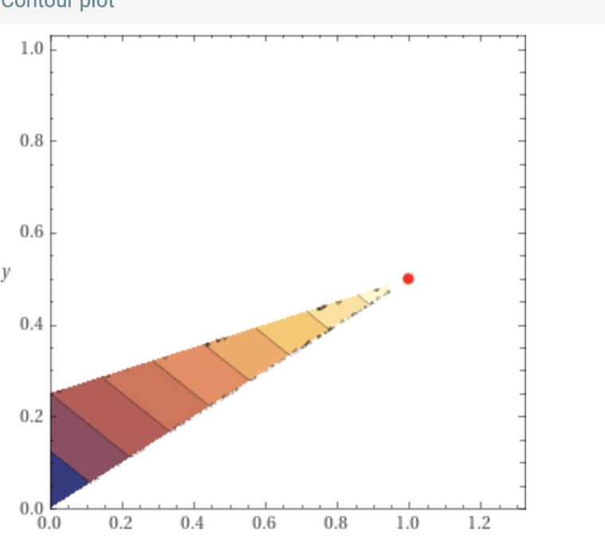